# Assignment 3: Graph Visualization

## Data 620 - 2.20.21

**This week's assignment is to:**

1. Load a graph database of your choosing from a text file or other source. If you take a large network dataset from the web (such as from https://snap.stanford.edu/data/), please feel free at this point to load just a small subset of the nodes and edges.
2. Create basic analysis on the graph, including the graph’s diameter, and at least one other metric of your choosing. You may either code the functions by hand (to build your intuition and insight), or use functions in an existing package.
3. Use a visualization tool of your choice (Neo4j, Gephi, etc.) to display information.
4. Please record a short video (~ 5 minutes), and submit a link to the video as part of your homework submission.

Parts 3 and 4 should be in your video presentation.

For this week's assignment, I chose the Enron Dataset as prepared and collected by the CALO Project. It contains data surrounding 150 users, mostly senior management from the now defunct Enron. The whole corpus contains 517,000 emails and has been made available through the Federal Enery Regulatory Commission for public use. Many different fields use this dataset for training (both machine and personnel) and testing of word based algrothrims or programs.

For our purposes in the assignment, the analysis is focused in the email network documentation. The dataset includes 36,692 nodes with 183,831 edges and contains 367,662 points. According to the snap.Stanford.edu site, the total diameter is 11.

```python
#package import
import networkx as nx
import pandas as pd
import matplotlib.pyplot as plt
from operator import itemgetter

import warnings;
warnings.filterwarnings('ignore');
```

```python
#Data Import and statistics
df = pd.read_table("Email-Enron.txt", sep = "	", names = ['FromNode','ToNode'])
```

```python
df.shape
```

```
(367662, 2)
```

```python
G= nx.from_pandas_dataframe(df,'FromNode','ToNode')
print(nx.info(G))
```

```
Name:
Type: Graph
Number of nodes: 36692
Number of edges: 183831
Average degree:  10.0202
```

```python
#nx.algorithms.diameter(G)
```

The total diameter can not be generated by simple means which leads us to conclude there is some degree of seperation.

In order to see the general shape of the data, I took a 1000 record sample from near the front of the data.

```python
#sample dataframe creation and statistics
df_explore=df[100:1100]
df_explore.shape
```

```
(1000, 2)
```

```python
df_explore.head()
```

|  | FromNode | ToNode |
| --- | --- | --- |
| 100 | 5 | 301 |
| 101 | 5 | 416 |
| 102 | 5 | 443 |
| 103 | 5 | 478 |
| 104 | 5 | 566 |

```python
G=nx.from_pandas_dataframe(df_explore, 'FromNode', 'ToNode')
```

```python
print(nx.info(G))
```

```
Name:
Type: Graph
Number of nodes: 599
Number of edges: 972
Average degree:   3.2454
```

```python
nx.algorithms.diameter(G)
```

```
5
```

Since I am not plotting the entire dataframe, we can get a general understanding of the links. Using this, we can define what our next steps could or should be.

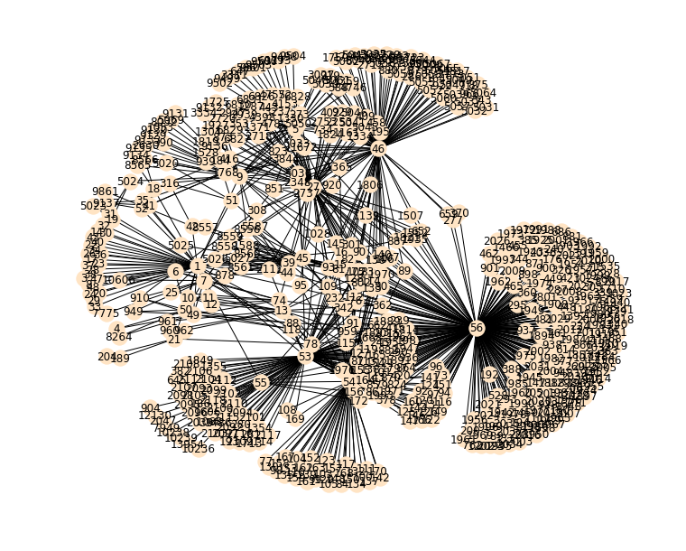

```python
%matplotlib inline
plt.rcParams['figure.figsize'] = (10, 8)
nx.draw(G, node_color='bisque', with_labels=True)
```

There seems to be key nodes the others connect to. This makes since as the data is based on a company's email, the nodes could the key players (Directors, VP's, C-level staff).

We will start by determining the "top" 10 nodes and seperating those values into a list.

```python
sc = nx.communicability_centrality(G)
```

```python
sorted_sc=sorted(sc.items(), key=itemgetter(1), reverse=True)
sorted_sc=sorted_sc[:10]
sorted_sc=pd.DataFrame(sorted_sc)
sorted_sc=sorted_sc[0]
sorted_sc=sorted_sc.values.tolist()
```

With the list, we will subset the orginial dataframe to only include nodes coming from these central nodes.

```python
central_df=df[df.FromNode.isin(sorted_sc)]
central_df.shape
```

```
(1697, 2)
```

```python
G= nx.from_pandas_dataframe(central_df,'FromNode','ToNode')
print(nx.info(G))
```

```
Name:
Type: Graph
Number of nodes: 1134
Number of edges: 1663
Average degree:   2.9330
```

```python
nx.algorithms.diameter(G)
```

```
4
```

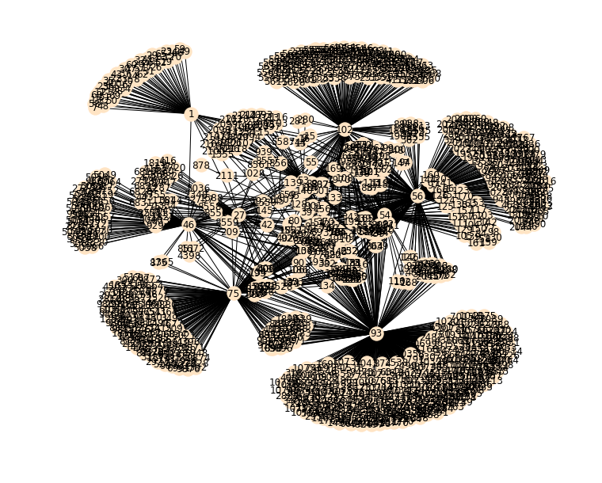

```python
%matplotlib inline
plt.rcParams['figure.figsize'] = (10, 8)
nx.draw(G, node_color='bisque', with_labels=True)
```

I think there is much more we can dive into this data from a network prespective.

- We can start breaking down twhich nodes which link these major nodes
- Does any of these subnodes share commonality with other major nodes?
- We can take each of the top nodes and break down the individual connections in each cluster, such as node 93.

References:

[1] Disney, Andrew (2008). Social network analysis 101: centrality measures explained. Cambridge Intelligence. Retrieved from: https://cambridge-intelligence.com/keylines-faqs-social-network-analysis/

SNAP Stanford. (2021). Enron email network [Data file]. Retrieved from https://snap.stanford.edu/data/email-Enron.html